# AutoML: Aus Yield Prediction

Zia Ahmed, Unversity at Buffalo

```r
setwd(gsub(pattern = '/scripts', replacement = '', x = getwd()))
```

# AutoML: Automatic Machine Learning

In recent years, the demand for machine learning experts has outpaced the supply, despite the surge of people entering the field. To address this gap, there have been big strides in the development of user-friendly machine learning software that can be used by non-experts. The first steps toward simplifying machine learning involved developing simple, unified interfaces to a variety of machine learning algorithms (e.g. H2O).

Although H2O has made it easy for non-experts to experiment with machine learning, there is still a fair bit of knowledge and background in data science that is required to produce high-performing machine learning models. Deep Neural Networks in particular are notoriously difficult for a non-expert to tune properly. In order for machine learning software to truly be accessible to non-experts, we have designed an easy-to-use interface which automates the process of training a large selection of candidate models. H2O’s AutoML can also be a helpful tool for the advanced user, by providing a simple wrapper function that performs a large number of modeling-related tasks that would typically require many lines of code, and by freeing up their time to focus on other aspects of the data science pipeline tasks such as data-preprocessing, feature engineering and model deployment.

H2O’s AutoML can be used for automating the machine learning workflow, which includes automatic training and tuning of many models within a user-specified time-limit. Stacked Ensembles – one based on all previously trained models, another one on the best model of each family – will be automatically trained on collections of individual models to produce highly predictive ensemble models which, in most cases, will be the top performing models in the AutoML Leaderboard.

H2O offers a number of model explainability methods that apply to AutoML objects (groups of models), as well as individual models (e.g. leader model). Explanations can be generated automatically with a single function call, providing a simple interface to exploring and explaining the AutoML models.

#### Set working directory

```r
#setwd("D:/Dropbox/CIMMYT_UB/NEW_ANALYSIS/ANALYSIS/AMAN")
setwd("/home/zia207/Dropbox/CIMMYT_UB/NEW_ANALYSIS/ANALYSIS/Yield/AUS/AutoML_Aus_Yield/NewAnalysis")
#setwd("C:\\Users\\zahmed2\\Dropbox\\CIMMYT_UB\\NEW_ANALYSIS\\ANALYSIS\\Yield\\AUS\\AutoML_Aus_Yield")
```

#### Load Pcakages

```r
library(plyr)
library(tidyverse)
library(dplyr)
library(classInt)
library(data.table)
library(magrittr)
library(DT)
require(reshape2)
library(pdp)       # for partial dependence plots (and ICE curves)
library(vip)       # for variable importance plots
library(iml)       # for general IML-related functions
library(DALEX)     # for general IML-related functions
library(lime)      # for local interpretable model-agnostic explanations
library(breakDown)
library(iBreakDown)
library(purrrlyr)
```

### Load data

```r
mf<-read.csv("aus_data_all.csv", header = T)
train.mf<-read.csv("train_data.csv", header = T)
test.mf<-read.csv("test_data.csv", header = T)
```

```r
names(mf)
```

```
##  [1] "Index"               "Crop"                "Seasons"
##  [4] "Crop_Types"          "Seasons_types"       "UNION_ID"
##  [7] "x"                   "y"                   "LONG"
## [10] "LAT"                 "DIVISION"            "DISTRICT"
## [13] "UPAZILA"             "UNION"               "Total_GWP"
## [16] "Emission_Intensity"  "YIELD"               "GD"
## [19] "N_rate"              "P_rate"              "K_rate"
## [22] "pH"                  "SOC"                 "N"
## [25] "P"                   "K"                   "S"
## [28] "Zn"                  "DEM"                 "NDVI_097"
## [31] "NDVI_113"            "NDVI_129"            "NDVI_145"
## [34] "NDVI_161"            "NDVI_177"            "NDVI_193"
## [37] "t2m_097"             "t2m_113"             "t2m_129"
## [40] "t2m_145"             "t2m_161"             "t2m_177"
## [43] "t2m_193"             "tp_097"              "tp_113"
## [46] "tp_129"              "tp_145"              "tp_161"
## [49] "tp_177"              "tp_193"              "LT_Class"
## [52] "General_Soil_type"   "DRC_Class"           "TZONE_Class"
## [55] "Water_regime"        "Manure"              "Soil_texture"
## [58] "LT_ID"               "DRC_ID"              "STYPE_ID"
## [61] "TZONE_ID"            "DRC_CLASS_old"       "DRC_old"
## [64] "New_DRC"             "Urea.Amount..Kg.ha." "MP.Amount..Kg.ha."
## [67] "TSP.Amount..Kg.ha."  "DAP.Amount..Kg.ha."
```

### Create data frame-function

```r
FeatureData <- function(data) {
  features <- c(
                "GD",              # 1
                "N_rate",          # 2
                "P_rate",          # 3
                "K_rate",          # 4

                "pH",              # 5
                "SOC",             # 6
                "N",               # 7
                "P",               # 8
                "K",               # 9
                "S",               # 10
                "Zn",              # 11

                "DEM",             # 12

                "NDVI_097",      # 13
                "NDVI_113",      # 14
                "NDVI_129",      # 15
                "NDVI_145",      # 16
                "NDVI_161",      # 17
                "NDVI_177",      # 18
                "NDVI_193",      # 19

                "t2m_097",      # 20
                "t2m_113",      # 21
                "t2m_129",      # 22
                "t2m_145",      # 23
                "t2m_161",      # 24
                "t2m_177",      # 25
                "t2m_193",      # 26

                "tp_097",       # 27
                "tp_113",       # 28
                "tp_129",       # 29
                "tp_145",       # 30
                "tp_161",       # 31
                "tp_177",       # 32
                "tp_193",       # 33


                "Crop_Types",        # 34
                "LT_Class",          # 35
                "General_Soil_type", # 36
                "DRC_Class",         # 37
                "TZONE_Class",       # 38
                "Soil_texture",      # 39
                "Water_regime",      # 40
                "Manure",            # 41

                "YIELD")            # 54
                fea <- data[,features]
                fea[, 1:33] = scale(fea[, 1:33])            # scale predictors
                fea[,34:41]= dmap(fea[,34:41], as.factor)   # convert to factors
                return(fea)
                 }
```

```r
df<-FeatureData(mf)
train.df<-FeatureData(train.mf)
test.df<-FeatureData(test.mf)
```

```r
write.csv(train.df, "train_data_scaled.csv", row.names = T)
write.csv(test.df, "test_data_scaled.csv", row.names = T)
```

### Connect to H2o server

```r
library(h2o)
h2o.init(nthreads = -1,max_mem_size ="48g",enable_assertions = FALSE)
```

```r
h2o.no_progress() # disable progress bar for RMarkdown
h2o.removeAll()   # Optional: remove anything from previous session
```

### Create h2o dataframe

```r
h_df<-  as.h2o(df)
h_train<-  as.h2o(train.df)
h_test<- as.h2o(test.df)
```

### Define response and predictors

```r
y <- "YIELD"
x <- setdiff(names(h_train), y)
```

### Create data frame for Explianers

### All Data

```r
x_all <- as.data.frame(h_df) %>% dplyr::select(-YIELD)
y_all<- as.data.frame(h_df) %>% pull(YIELD)
```

### Training

```r
x_train <- as.data.frame(h_train) %>% dplyr::select(-YIELD)
y_train <- as.data.frame(h_train) %>% pull(YIELD)
```

### Test

```r
x_test <- as.data.frame(h_test) %>% dplyr::select(-YIELD)
y_test <- as.data.frame(h_test) %>% pull(YIELD)
```

# Auto ML

```r
train.aml <- h2o.automl(
                  x= x,
                  y = y,
                  training_frame = h_train,
                  nfolds=10,
                  keep_cross_validation_predictions = TRUE,
                  stopping_metric = "RMSE",
                  stopping_tolerance = 0.001,
                  stopping_rounds = 3,
                  max_runtime_secs_per_model = 0,
                  seed = 42,
                  #max_models = 20,
                  project_name = "AutoML_trainings")
```

## Leaderboard

Next, we will view the AutoML Leaderboard. A default performance metric for each machine learning task (binary classification, multiclass classification, regression) is specified internally and the leaderboard will be sorted by that metric. In the case of regression, the default ranking metric is mean residual deviance. In the future, the user will be able to specify any of the H2O metrics so that different metrics can be used to generate rankings on the leaderboard.

```r
lb <- h2o.get_leaderboard(object = train.aml, extra_columns = "ALL")
datatable(as.data.frame(lb),
          rownames = FALSE, options = list(pageLength = 10, scrollX = TRUE, round)) %>%
  formatRound(columns = -1, digits = 4)
write.csv(as.data.frame(lb), "Model_Stat_AutoML.csv", row.names = F)
```

### The best Model

```r
best_ML<- h2o.get_best_model(train.aml, criterion = "RMSE" )
best_ML
```

```
## Model Details:
## ==============
##
## H2ORegressionModel: stackedensemble
## Model ID:  StackedEnsemble_AllModels_4_AutoML_5_20211128_82339
## Number of Base Models: 958
##
## Base Models (count by algorithm type):
##
## deeplearning          drf          gbm          glm      xgboost
##           18            2          769            1          168
##
## Metalearner:
##
## Metalearner algorithm: glm
## Metalearner cross-validation fold assignment:
##   Fold assignment scheme: AUTO
##   Number of folds: 10
##   Fold column: NULL
## Metalearner hyperparameters:
##
##
## H2ORegressionMetrics: stackedensemble
## ** Reported on training data. **
##
## MSE:  163840.9
## RMSE:  404.7727
## MAE:  309.8961
## RMSLE:  0.1915659
## Mean Residual Deviance :  163840.9
##
##
##
## H2ORegressionMetrics: stackedensemble
## ** Reported on cross-validation data. **
## ** 10-fold cross-validation on training data (Metrics computed for combined holdout predictions) **
##
## MSE:  698943
## RMSE:  836.0281
## MAE:  637.3305
## RMSLE:  0.3523373
## Mean Residual Deviance :  698943
```

### Save Model

```r
model_path <- h2o.saveModel(object = best_ML, path = getwd(), force = TRUE)
print(model_path)
```

```
## [1] "/home/zia207/Dropbox/CIMMYT_UB/NEW_ANALYSIS/ANALYSIS/Yield/AUS/AutoML_Aus_Yield/NewAnalysis/StackedEnsemble_AllModels_4_AutoML_5_20211128_82339"
```

### The best Stack Ensemble of all models

```r
model_ids<-as.data.frame(lb)$model_id
stack_all<-h2o.getModel(grep("StackedEnsemble_AllModels", model_ids, value=TRUE)[1])
stack_all_meta<-stack_all@model$metalearner_model
stack_all_meta
```

```
## Model Details:
## ==============
##
## H2ORegressionModel: glm
## Model ID:  metalearner_AUTO_StackedEnsemble_AllModels_4_AutoML_5_20211128_82339
## GLM Model: summary
##     family     link                                regularization
## 1 gaussian identity Elastic Net (alpha = 0.5, lambda = 190070.0 )
##   number_of_predictors_total number_of_active_predictors number_of_iterations
## 1                        958                          13                    1
##                                                          training_frame
## 1 levelone_training_StackedEnsemble_AllModels_4_AutoML_5_20211128_82339
##
## Coefficients: glm coefficients
##                                                 names coefficients
## 1                                           Intercept   600.350631
## 2        GBM_grid_1_AutoML_5_20211128_82339_model_435     0.000000
## 3 DeepLearning_grid_1_AutoML_5_20211128_82339_model_2     0.053698
## 4        GBM_grid_1_AutoML_5_20211128_82339_model_673     0.000000
## 5        GBM_grid_1_AutoML_5_20211128_82339_model_202     0.000000
##   standardized_coefficients
## 1               3132.806084
## 2                  0.000000
## 3                 52.946800
## 4                  0.000000
## 5                  0.000000
##
## ---
##                                                   names coefficients
## 954 DeepLearning_grid_2_AutoML_5_20211128_82339_model_4     0.000000
## 955 DeepLearning_grid_3_AutoML_5_20211128_82339_model_4     0.000000
## 956         GBM_grid_1_AutoML_5_20211128_82339_model_96     0.000000
## 957        GBM_grid_1_AutoML_5_20211128_82339_model_764     0.000000
## 958                       GLM_1_AutoML_5_20211128_82339     0.000000
## 959    XGBoost_grid_1_AutoML_5_20211128_82339_model_165     0.000000
##     standardized_coefficients
## 954                  0.000000
## 955                  0.000000
## 956                  0.000000
## 957                  0.000000
```

[output cut: 59 more lines]

```
## mse                      671254.900000   758071.500000   455991.660000
## null_deviance          75825040.000000 79121296.000000 48149120.000000
## r2                            0.523492        0.585469        0.546251
## residual_deviance      35576508.000000 32597076.000000 21431608.000000
## rmse                        819.301450      870.673030      675.271550
## rmsle                         0.331036        0.433002        0.269719
##                             cv_8_valid      cv_9_valid     cv_10_valid
## mae                         590.027040      713.264000      610.646500
## mean_residual_deviance   680381.300000   833396.800000   680596.750000
## mse                      680381.300000   833396.800000   680596.750000
## null_deviance          80019224.000000 90579904.000000 60740184.000000
## r2                            0.523149        0.480765        0.430498
## residual_deviance      37420972.000000 45836824.000000 34029836.000000
## rmse                        824.852300      912.905700      824.982850
## rmsle                         0.443195        0.397856        0.299740
```

### The best Stack Ensemble best of family

```r
stack_best<-h2o.getModel(grep("StackedEnsemble_BestOfFamily", model_ids, value=TRUE)[1])
stack_best_meta<-stack_best@model$metalearner_model
stack_best_meta
```

```
## Model Details:
## ==============
##
## H2ORegressionModel: glm
## Model ID:  metalearner_AUTO_StackedEnsemble_BestOfFamily_4_AutoML_5_20211128_82339
## GLM Model: summary
##     family     link                              regularization
## 1 gaussian identity Elastic Net (alpha = 0.5, lambda = 1697.2 )
##   number_of_predictors_total number_of_active_predictors number_of_iterations
## 1                          6                           3                    1
##                                                             training_frame
## 1 levelone_training_StackedEnsemble_BestOfFamily_4_AutoML_5_20211128_82339
##
## Coefficients: glm coefficients
##                                                 names coefficients
## 1                                           Intercept   111.031327
## 2        GBM_grid_1_AutoML_5_20211128_82339_model_435     0.311688
## 3 DeepLearning_grid_1_AutoML_5_20211128_82339_model_2     0.461580
## 4                       DRF_1_AutoML_5_20211128_82339     0.191093
## 5                       XRT_1_AutoML_5_20211128_82339     0.000000
## 6    XGBoost_grid_1_AutoML_5_20211128_82339_model_114     0.000000
## 7                       GLM_1_AutoML_5_20211128_82339     0.000000
##   standardized_coefficients
## 1               3132.806084
## 2                283.643694
## 3                455.120128
## 4                166.080044
## 5                  0.000000
## 6                  0.000000
## 7                  0.000000
##
## H2ORegressionMetrics: glm
## ** Reported on training data. **
##
## MSE:  690915
## RMSE:  831.213
## MAE:  618.0793
## RMSLE:  0.3438176
## Mean Residual Deviance :  690915
## R^2 :  0.5284454
```

[output cut: 47 more lines]

```
## mse                      527852.900000   713519.560000   719352.000000
## null_deviance          59834904.000000 56370252.000000 84611576.000000
## r2                            0.508057        0.328870        0.604700
## residual_deviance      27976200.000000 30681340.000000 33090194.000000
## rmse                        726.534850      844.700870      848.146240
## rmsle                         0.341568        0.262406        0.383207
##                             cv_8_valid      cv_9_valid     cv_10_valid
## mae                         673.352200      583.308040      654.213000
## mean_residual_deviance   860111.060000   674222.900000   697027.560000
## mse                      860111.060000   674222.900000   697027.560000
## null_deviance          85707560.000000 80985896.000000 80392088.000000
## r2                            0.445965        0.533365        0.574087
## residual_deviance      47306108.000000 37756480.000000 34154348.000000
## rmse                        927.421750      821.110700      834.881800
## rmsle                         0.380521        0.337940        0.352628
```

### The best Stack

```r
best_stack <- h2o.get_best_model(train.aml, algorithm = "stackedensemble", criterion = "RMSE" )
best_stack
```

```
## Model Details:
## ==============
##
## H2ORegressionModel: stackedensemble
## Model ID:  StackedEnsemble_AllModels_4_AutoML_5_20211128_82339
## Number of Base Models: 958
##
## Base Models (count by algorithm type):
##
## deeplearning          drf          gbm          glm      xgboost
##           18            2          769            1          168
##
## Metalearner:
##
## Metalearner algorithm: glm
## Metalearner cross-validation fold assignment:
##   Fold assignment scheme: AUTO
##   Number of folds: 10
##   Fold column: NULL
## Metalearner hyperparameters:
##
##
## H2ORegressionMetrics: stackedensemble
## ** Reported on training data. **
##
## MSE:  163840.9
## RMSE:  404.7727
## MAE:  309.8961
## RMSLE:  0.1915659
## Mean Residual Deviance :  163840.9
##
##
##
## H2ORegressionMetrics: stackedensemble
## ** Reported on cross-validation data. **
## ** 10-fold cross-validation on training data (Metrics computed for combined holdout predictions) **
##
## MSE:  698943
## RMSE:  836.0281
## MAE:  637.3305
## RMSLE:  0.3523373
## Mean Residual Deviance :  698943
```

### The best GLM

```r
best_GLM <- h2o.get_best_model(train.aml, algorithm = "glm", criterion = "RMSE" )
best_GLM
```

```
## Model Details:
## ==============
##
## H2ORegressionModel: glm
## Model ID:  GLM_1_AutoML_5_20211128_82339
## GLM Model: summary
##     family     link             regularization
## 1 gaussian identity Ridge ( lambda = 14082.0 )
##                                                                    lambda_search
## 1 nlambda = 30, lambda.max = 50164.0, lambda.min = 14082.0, lambda.1se = 50164.0
##   number_of_predictors_total number_of_active_predictors number_of_iterations
## 1                         76                          76                    5
##                                         training_frame
## 1 AutoML_5_20211128_82339_training_train.df_sid_b4ac_3
##
## Coefficients: glm coefficients
##                                               names coefficients
## 1                                         Intercept  3132.807572
## 2                General_Soil_type.Acid Basin Clays     0.002816
## 3             General_Soil_type.Acid Sulphate Soils    -0.004420
## 4              General_Soil_type.Black Terrai Soils     0.000244
## 5 General_Soil_type.Calcareous Aluvium (non-saline)    -0.002002
##   standardized_coefficients
## 1               3132.807572
## 2                  0.002816
## 3                 -0.004420
## 4                  0.000244
## 5                 -0.002002
##
## ---
##     names coefficients standardized_coefficients
## 72 tp_113    -0.010690                 -0.010690
## 73 tp_129    -0.001301                 -0.001301
## 74 tp_145     0.002095                  0.002095
## 75 tp_161    -0.009252                 -0.009252
## 76 tp_177    -0.005877                 -0.005877
## 77 tp_193    -0.007961                 -0.007961
##
## H2ORegressionMetrics: glm
## ** Reported on training data. **
```

[output cut: 54 more lines]

```
## mse                     1299993.800000   1950254.000000  1648233.800000
## null_deviance          68906720.000000 103369208.000000 85715696.000000
## r2                           -0.003731        -0.004149        0.000072
## residual_deviance      68899672.000000 103363464.000000 85708152.000000
## rmse                       1140.172700      1396.515000     1283.835600
## rmsle                         0.404139         0.650023        0.487384
##                             cv_8_valid      cv_9_valid     cv_10_valid
## mae                         942.411500      875.357100      933.465330
## mean_residual_deviance  1328218.600000  1228940.200000  1240564.600000
## mse                     1328218.600000  1228940.200000  1240564.600000
## null_deviance          69073432.000000 63910724.000000 64518488.000000
## r2                            0.000087       -0.003681       -0.031888
## residual_deviance      69067368.000000 63904892.000000 64509360.000000
## rmse                       1152.483600     1108.575800     1113.806400
## rmsle                         0.484832        0.438117        0.407224
```

### The best DRF

```r
best_DRF <- h2o.get_best_model(train.aml, algorithm = "DRF", criterion = "RMSE" )
best_DRF
```

```
## Model Details:
## ==============
##
## H2ORegressionModel: drf
## Model ID:  DRF_1_AutoML_5_20211128_82339
## Model Summary:
##   number_of_trees number_of_internal_trees model_size_in_bytes min_depth
## 1              38                       38              115107        16
##   max_depth mean_depth min_leaves max_leaves mean_leaves
## 1        20   19.42105        218        257   236.21053
##
##
## H2ORegressionMetrics: drf
## ** Reported on training data. **
## ** Metrics reported on Out-Of-Bag training samples **
##
## MSE:  789282.6
## RMSE:  888.4158
## MAE:  655.2418
## RMSLE:  0.3662242
## Mean Residual Deviance :  789282.6
##
##
##
## H2ORegressionMetrics: drf
## ** Reported on cross-validation data. **
## ** 10-fold cross-validation on training data (Metrics computed for combined holdout predictions) **
##
## MSE:  757317.7
## RMSE:  870.24
## MAE:  635.9812
## RMSLE:  0.3590159
## Mean Residual Deviance :  757317.7
##
##
## Cross-Validation Metrics Summary:
##                                 mean            sd     cv_1_valid    cv_2_valid
## mae                       639.808700     80.581726     776.245600    647.255250
## mean_residual_deviance 766574.600000 194590.470000 1141234.800000 793250.400000
## mse                    766574.600000 194590.470000 1141234.800000 793250.400000
## r2                          0.468725      0.111731       0.257858      0.400849
## residual_deviance      766574.600000 194590.470000 1141234.800000 793250.400000
## rmse                      869.495800    108.277840    1068.285900    890.646060
## rmsle                       0.351001      0.088143       0.465492      0.270212
##                           cv_3_valid    cv_4_valid    cv_5_valid     cv_6_valid
## mae                       679.021670    589.751400    574.780760     778.879940
## mean_residual_deviance 790352.060000 751947.200000 537033.900000 1027703.560000
## mse                    790352.060000 751947.200000 537033.900000 1027703.560000
## r2                          0.358387      0.576009      0.585354       0.470855
## residual_deviance      790352.060000 751947.200000 537033.900000 1027703.560000
## rmse                      889.017460    867.148860    732.825900    1013.757140
## rmsle                       0.323525      0.379487      0.270327       0.522498
##                           cv_7_valid    cv_8_valid    cv_9_valid   cv_10_valid
## mae                       586.547240    619.450870    573.129460    573.025000
## mean_residual_deviance 663996.600000 792393.900000 575730.800000 592102.800000
## mse                    663996.600000 792393.900000 575730.800000 592102.800000
## r2                          0.597176      0.403468      0.529798      0.507495
## residual_deviance      663996.600000 792393.900000 575730.800000 592102.800000
## rmse                      814.859860    890.165100    758.769300    769.482200
## rmsle                       0.319661      0.395726      0.290774      0.272308
```

### The best XRT

```r
best_XRT<-h2o.getModel(grep("XRT", model_ids, value=TRUE)[1])
best_XRT
```

```
## Model Details:
## ==============
##
## H2ORegressionModel: drf
## Model ID:  XRT_1_AutoML_5_20211128_82339
## Model Summary:
##   number_of_trees number_of_internal_trees model_size_in_bytes min_depth
## 1              36                       36              106624        16
##   max_depth mean_depth min_leaves max_leaves mean_leaves
## 1        20   19.19445        206        255   230.86111
##
##
## H2ORegressionMetrics: drf
## ** Reported on training data. **
## ** Metrics reported on Out-Of-Bag training samples **
##
## MSE:  825722.2
## RMSE:  908.6926
## MAE:  666.3376
## RMSLE:  0.3691365
## Mean Residual Deviance :  825722.2
##
##
##
## H2ORegressionMetrics: drf
## ** Reported on cross-validation data. **
## ** 10-fold cross-validation on training data (Metrics computed for combined holdout predictions) **
##
## MSE:  780911.5
## RMSE:  883.692
## MAE:  645.6133
## RMSLE:  0.3641147
## Mean Residual Deviance :  780911.5
##
##
## Cross-Validation Metrics Summary:
##                                 mean            sd     cv_1_valid    cv_2_valid
## mae                       645.737900     69.088280     776.910160    648.408600
## mean_residual_deviance 782564.940000 194772.250000 1117833.500000 792473.100000
## mse                    782564.940000 194772.250000 1117833.500000 792473.100000
## r2                          0.458331      0.114441       0.273076      0.401436
## residual_deviance      782564.940000 194772.250000 1117833.500000 792473.100000
## rmse                      878.402470    110.423676    1057.276500    890.209600
## rmsle                       0.355838      0.083911       0.461499      0.273969
##                           cv_3_valid    cv_4_valid    cv_5_valid    cv_6_valid
## mae                       677.100460    673.070740    580.281250    723.175350
## mean_residual_deviance 900376.750000 967186.100000 533366.200000 928451.800000
## mse                    900376.750000 967186.100000 533366.200000 928451.800000
## r2                          0.269069      0.454645      0.588186      0.521958
## residual_deviance      900376.750000 967186.100000 533366.200000 928451.800000
## rmse                      948.881840    983.456200    730.319200    963.562100
## rmsle                       0.339699      0.413428      0.274305      0.515171
##                           cv_7_valid    cv_8_valid    cv_9_valid   cv_10_valid
## mae                       621.481300    606.321400    546.394840    604.234900
## mean_residual_deviance 717543.500000 713842.500000 530664.800000 623911.000000
## mse                    717543.500000 713842.500000 530664.800000 623911.000000
## r2                          0.564691      0.462603      0.566604      0.481038
## residual_deviance      717543.500000 713842.500000 530664.800000 623911.000000
## rmse                      847.079400    844.892000    728.467470    789.880400
## rmsle                       0.326140      0.374048      0.293546      0.286574
```

### The best GBM

```r
best_GBM <- h2o.get_best_model(train.aml, algorithm = "GBM", criterion = "RMSE" )
best_GBM
```

```
## Model Details:
## ==============
##
## H2ORegressionModel: gbm
## Model ID:  GBM_grid_1_AutoML_5_20211128_82339_model_435
## Model Summary:
##   number_of_trees number_of_internal_trees model_size_in_bytes min_depth
## 1              91                       91               39943         7
##   max_depth mean_depth min_leaves max_leaves mean_leaves
## 1         7    7.00000         15         47    30.23077
##
##
## H2ORegressionMetrics: gbm
## ** Reported on training data. **
##
## MSE:  191470.8
## RMSE:  437.5738
## MAE:  317.8408
## RMSLE:  0.188603
## Mean Residual Deviance :  191470.8
##
##
##
## H2ORegressionMetrics: gbm
## ** Reported on cross-validation data. **
## ** 10-fold cross-validation on training data (Metrics computed for combined holdout predictions) **
##
## MSE:  734949.2
## RMSE:  857.2918
## MAE:  644.1111
## RMSLE:  0.3534021
## Mean Residual Deviance :  734949.2
##
##
## Cross-Validation Metrics Summary:
##                                 mean            sd     cv_1_valid    cv_2_valid
## mae                       643.628400     63.190006     770.547060    605.432600
## mean_residual_deviance 740032.000000 175728.810000 1105712.400000 687846.560000
## mse                    740032.000000 175728.810000 1105712.400000 687846.560000
## r2                          0.488930      0.088392       0.280958      0.480462
## residual_deviance      740032.000000 175728.810000 1105712.400000 687846.560000
## rmse                      855.090150     99.178880    1051.528600    829.365200
## rmsle                       0.345313      0.079411       0.464516      0.266315
##                           cv_3_valid    cv_4_valid    cv_5_valid    cv_6_valid
## mae                       663.405000    647.397030    596.866800    737.246460
## mean_residual_deviance 706553.560000 841438.940000 550218.800000 922379.750000
## mse                    706553.560000 841438.940000 550218.800000 922379.750000
## r2                          0.426416      0.525549      0.575174      0.525084
## residual_deviance      706553.560000 841438.940000 550218.800000 922379.750000
## rmse                      840.567400    917.299800    741.767330    960.406000
## rmsle                       0.312854      0.394648      0.276314      0.476944
##                           cv_7_valid    cv_8_valid    cv_9_valid   cv_10_valid
## mae                       623.849060    603.614560    600.579600    587.346100
## mean_residual_deviance 708732.800000 735854.750000 606247.000000 535335.560000
## mse                    708732.800000 735854.750000 606247.000000 535335.560000
## r2                          0.570036      0.446032      0.504875      0.554714
## residual_deviance      708732.800000 735854.750000 606247.000000 535335.560000
## rmse                      841.862730    857.819760    778.618650    731.666260
## rmsle                       0.318693      0.381643      0.293367      0.267833
```

### The best XGBoost

```r
best_XGBoost <- h2o.get_best_model(train.aml, algorithm = "xgboost", criterion = "RMSE" )
best_XGBoost
```

```
## Model Details:
## ==============
##
## H2ORegressionModel: xgboost
## Model ID:  XGBoost_grid_1_AutoML_5_20211128_82339_model_114
## Model Summary:
##   number_of_trees
## 1             124
##
##
## H2ORegressionMetrics: xgboost
## ** Reported on training data. **
##
## MSE:  158073.4
## RMSE:  397.5845
## MAE:  274.3532
## RMSLE:  0.1763701
## Mean Residual Deviance :  158073.4
##
##
##
## H2ORegressionMetrics: xgboost
## ** Reported on cross-validation data. **
## ** 10-fold cross-validation on training data (Metrics computed for combined holdout predictions) **
##
## MSE:  783374.2
## RMSE:  885.0843
## MAE:  657.0198
## RMSLE:  0.3659152
## Mean Residual Deviance :  783374.2
##
##
## Cross-Validation Metrics Summary:
##                                 mean            sd     cv_1_valid    cv_2_valid
## mae                       656.888370     63.107998     791.781560    652.128600
## mean_residual_deviance 782816.100000 164098.470000 1100287.800000 807050.000000
## mse                    782816.100000 164098.470000 1100287.800000 807050.000000
## r2                          0.458210      0.081882       0.284486      0.390426
## residual_deviance      782816.100000 164098.470000 1100287.800000 807050.000000
## rmse                      880.501040     91.494080    1048.946000    898.359600
## rmsle                       0.359185      0.072391       0.456197      0.307469
##                           cv_3_valid    cv_4_valid    cv_5_valid    cv_6_valid
## mae                       598.921500    667.610900    577.704160    722.296260
## mean_residual_deviance 666288.560000 914413.700000 566537.100000 935854.200000
## mse                    666288.560000 914413.700000 566537.100000 935854.200000
## r2                          0.459103      0.484401      0.562574      0.518147
## residual_deviance      666288.560000 914413.700000 566537.100000 935854.200000
## rmse                      816.265000    956.249800    752.686600    967.395570
## rmsle                       0.302867      0.408279      0.297785      0.488607
##                           cv_7_valid    cv_8_valid    cv_9_valid   cv_10_valid
## mae                       652.088200    650.150900    658.722840    597.478940
## mean_residual_deviance 764925.600000 765943.940000 707278.800000 599581.900000
## mse                    764925.600000 765943.940000 707278.800000 599581.900000
## r2                          0.535945      0.423380      0.422362      0.501274
## residual_deviance      764925.600000 765943.940000 707278.800000 599581.900000
## rmse                      874.600300    875.182250    840.998660    774.326700
## rmsle                       0.345209      0.387700      0.317456      0.280280
```

### The best DNN

```r
best_DNN <- h2o.get_best_model(train.aml, algorithm = "DeepLearning", criterion = "RMSE" )
best_DNN
```

```
## Model Details:
## ==============
##
## H2ORegressionModel: deeplearning
## Model ID:  DeepLearning_grid_1_AutoML_5_20211128_82339_model_2
## Status of Neuron Layers: predicting YIELD, regression, gaussian distribution, Quadratic loss, 8,501 weights/biases, 109.1 KB, 1,546,440 training samples, mini-batch size 1
##   layer units             type dropout       l1       l2 mean_rate rate_rms
## 1     1    83            Input  0.00 %       NA       NA        NA       NA
## 2     2   100 RectifierDropout 20.00 % 0.000000 0.000000  0.099502 0.290854
## 3     3     1           Linear      NA 0.000000 0.000000  0.000318 0.000105
##   momentum mean_weight weight_rms mean_bias bias_rms
## 1       NA          NA         NA        NA       NA
## 2 0.000000   -0.016920   0.129060  0.270469 0.086918
## 3 0.000000    0.007956   0.314649 -0.201844 0.000000
##
##
## H2ORegressionMetrics: deeplearning
## ** Reported on training data. **
## ** Metrics reported on full training frame **
##
## MSE:  204765.9
## RMSE:  452.5106
## MAE:  317.5668
## RMSLE:  0.1994752
## Mean Residual Deviance :  204765.9
##
##
##
## H2ORegressionMetrics: deeplearning
## ** Reported on cross-validation data. **
## ** 10-fold cross-validation on training data (Metrics computed for combined holdout predictions) **
##
## MSE:  738397.3
## RMSE:  859.3005
## MAE:  635.1058
## RMSLE:  NaN
## Mean Residual Deviance :  738397.3
##
##
## Cross-Validation Metrics Summary:
```

[output cut: 9 more lines]

```
## mae                       682.654050    585.065700    529.343200    637.760900
## mean_residual_deviance 825872.600000 663593.440000 463004.530000 737066.750000
## mse                    825872.600000 663593.440000 463004.530000 737066.750000
## r2                          0.329552      0.625828      0.642512      0.620498
## residual_deviance      825872.600000 663593.440000 463004.530000 737066.750000
## rmse                      908.775300    814.612400    680.444340    858.525900
## rmsle                       0.330993      0.371212      0.267085      0.369257
##                           cv_7_valid    cv_8_valid    cv_9_valid   cv_10_valid
## mae                       630.315730    576.180400    606.136600    664.128400
## mean_residual_deviance 684443.750000 695970.560000 640227.800000 754498.700000
## mse                    684443.750000 695970.560000 640227.800000 754498.700000
## r2                          0.584771      0.476058      0.477123      0.372416
## residual_deviance      684443.750000 695970.560000 640227.800000 754498.700000
## rmse                      827.311160    834.248540    800.142400    868.618840
## rmsle                       0.324147      0.359192      0.293270      0.328856
```

## Cross-validation results

```r
# Stack Ensemble of all model
cv.stack_all<-stack_all_meta@model$cross_validation_metrics_summary
write.csv(cv.stack_all, "cv.stack_all.csv")

# Stack Ensemble the best of family
cv.stack_best<-stack_best_meta@model$cross_validation_metrics_summary
write.csv(cv.stack_best, "cv.stack_best.csv")

# GLM
cv.GLM<-best_GLM@model$cross_validation_metrics_summary
write.csv(cv.GLM, "cv_best_GML.csv")

# DRF
cv.DRF<-best_DRF@model$cross_validation_metrics_summary
write.csv(cv.DRF, "cv_best_DRF.csv")

# XRT
cv.XRT<-best_XRT@model$cross_validation_metrics_summary
write.csv(cv.XRT, "cv_best_XRT.csv")

# GBM
cv.GBM<-best_GBM@model$cross_validation_metrics_summary
write.csv(cv.GBM, "cv_best_GBM.csv")

# XGBoost
cv.XGBoost<-best_XGBoost@model$cross_validation_metrics_summary
write.csv(cv.XGBoost, "cv_best_XGBoost.csv")

# DNN
cv.DNN<-best_DNN@model$cross_validation_metrics_summary
write.csv(cv.DNN, "cv_best_DNN.csv")
```

## RMSE - CV

```r
## Create a data-frame
glm.RMSE<-cv.GLM[7,c(1:2)]
drf.RMSE<-cv.DRF[6,c(1:2)]
xrt.RMSE<-cv.XRT[6,c(1:2)]
gbm.RMSE<-cv.GBM[6,c(1:2)]
xgboost.RMSE<-cv.XGBoost[6,c(1:2)]
dnn.RMSE<-cv.DNN[6,c(1:2)]
stack_all.RMSE<-cv.stack_all[7,c(1:2)]
stack_best.RMSE<-cv.stack_best[7,c(1:2)]

cv.RMSE<-rbind(glm.RMSE, drf.RMSE, xrt.RMSE, gbm.RMSE,
                   xgboost.RMSE, dnn.RMSE, stack_all.RMSE, stack_best.RMSE )

rownames(cv.RMSE) <- c("GLM ", "DRF ", "XRT", "GBM", "XGBoost", "DNN",
                           "Stack-Ensemble (all models)", "Stack-Ensemble (the best of family)")
cv.RMSE <- tibble::rownames_to_column(cv.RMSE, "Models")
cv.RMSE <-arrange(cv.RMSE ,desc(mean))

## Plot
tiff( file="FIGURE_CV_RMSE_aman.tif",
      width=7,   height=5,
      units = "in",
      pointsize = 10,
      res=600, bg = "white",
      compression =  "lzw")

cv.RMSE.p<-ggplot(cv.RMSE, aes(y=mean, x=reorder(Models, +mean))) +
  ylab('') +
  xlab('')+
  geom_point(colour = "black", size = 2.5)+
  geom_errorbar(aes(ymin=mean-sd,
                    ymax=mean+sd),
                width=.2,
                linetype=1,
                color ="dark grey") +
   #scale_y_continuous(limits=c(0.6,1), breaks=seq(0.6, 1, 0.2)) +
   theme(axis.line = element_line(colour = "grey"),
        axis.text.y=element_text(size=12),
        axis.text.x = element_text(size=10),
        axis.title.x = element_text(size=12),
        axis.title.y = element_text(size=12))+
  coord_flip()
print(cv.RMSE.p)
dev.off()
```

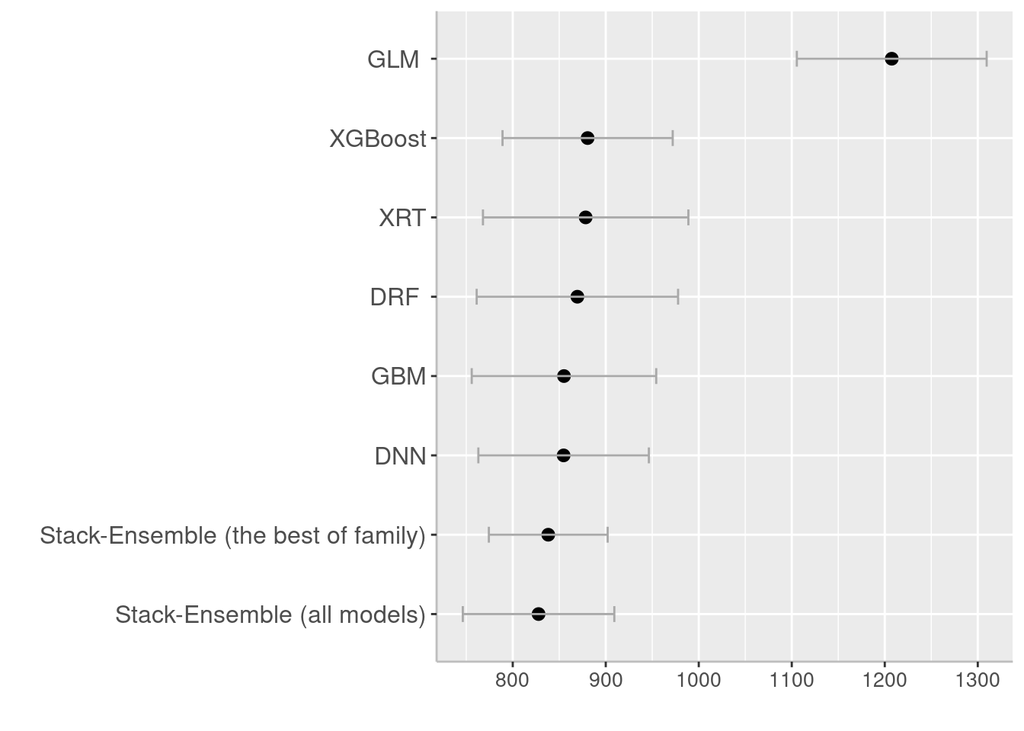

```r
print(cv.RMSE.p)
```

## MAE - CV

```r
## Create a data-frame
glm.MAE<-cv.GLM[1,c(1:2)]
drf.MAE<-cv.DRF[1,c(1:2)]
xrt.MAE<-cv.XRT[1,c(1:2)]
gbm.MAE<-cv.GBM[1,c(1:2)]
xgboost.MAE<-cv.XGBoost[1,c(1:2)]
dnn.MAE<-cv.DNN[1,c(1:2)]
stack_all.MAE<-cv.stack_all[1,c(1:2)]
stack_best.MAE<-cv.stack_best[1,c(1:2)]

cv.MAE<-rbind(glm.MAE, drf.MAE, xrt.MAE, gbm.MAE,
               xgboost.MAE, dnn.MAE, stack_all.MAE, stack_best.MAE )

rownames(cv.MAE) <- c("GLM ", "DRF ", "XRT", "GBM", "XGBoost", "DNN",
                       "Stack-Ensemble (all models)", "Stack-Ensemble (the best of family)")
cv.MAE <- tibble::rownames_to_column(cv.MAE, "Models")
cv.MAE <-arrange(cv.MAE ,desc(mean))

## Plot
tiff( file="FIGURE_CV_MAE_aman.tif",
      width=7,   height=5,
      units = "in",
      pointsize = 10,
      res=600, bg = "white",
      compression =  "lzw")

cv.MAE.p<-ggplot(cv.MAE, aes(y=mean, x=reorder(Models, +mean))) +
  ylab('') +
  xlab('')+
  geom_point(colour = "black", size = 2.5)+
  geom_errorbar(aes(ymin=mean-sd,
                    ymax=mean+sd),
                width=.2,
                linetype=1,
                color ="dark grey") +
  #scale_y_continuous(limits=c(0.6,1), breaks=seq(0.6, 1, 0.2)) +
  theme(axis.line = element_line(colour = "grey"),
        axis.text.y=element_text(size=12),
        axis.text.x = element_text(size=10),
        axis.title.x = element_text(size=12),
        axis.title.y = element_text(size=12))+
  coord_flip()
print(cv.MAE.p)
dev.off()
```

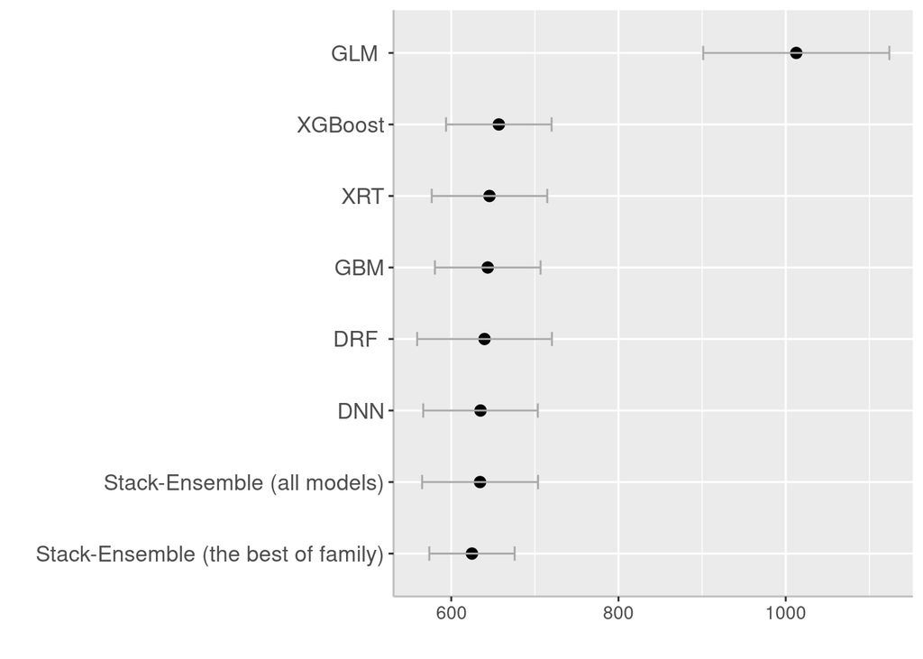

```r
print(cv.MAE.p)
```

## R2 - CV

```r
## Create a data-frame
glm.R2<-cv.GLM[5,c(1:2)]
drf.R2<-cv.DRF[4,c(1:2)]
xrt.R2<-cv.XRT[4,c(1:2)]
gbm.R2<-cv.GBM[4,c(1:2)]
xgboost.R2<-cv.XGBoost[4,c(1:2)]
dnn.R2<-cv.DNN[4,c(1:2)]
stack_all.R2<-cv.stack_all[5,c(1:2)]
stack_best.R2<-cv.stack_best[5,c(1:2)]

cv.R2<-rbind(glm.R2, drf.R2, xrt.R2, gbm.R2,
               xgboost.R2, dnn.R2, stack_all.R2, stack_best.R2 )

rownames(cv.R2) <- c("GLM ", "DRF ", "XRT", "GBM", "XGBoost", "DNN",
                       "Stack-Ensemble (all models)", "Stack-Ensemble (the best of family)")
cv.R2 <- tibble::rownames_to_column(cv.R2, "Models")
cv.R2 <-arrange(cv.R2 ,desc(mean))

## Plot
tiff( file="FIGURE_CV_R2_aman.tif",
      width=7,   height=5,
      units = "in",
      pointsize = 10,
      res=600, bg = "white",
      compression =  "lzw")

cv.R2.p<-ggplot(cv.R2, aes(y=mean, x=reorder(Models, +mean))) +
  ylab('') +
  xlab('')+
  geom_point(colour = "black", size = 2.5)+
  geom_errorbar(aes(ymin=mean-sd,
                    ymax=mean+sd),
                width=.2,
                linetype=1,
                color ="dark grey") +
  #scale_y_continuous(limits=c(0.6,1), breaks=seq(0.6, 1, 0.2)) +
  theme(axis.line = element_line(colour = "grey"),
        axis.text.y=element_text(size=12),
        axis.text.x = element_text(size=10),
        axis.title.x = element_text(size=12),
        axis.title.y = element_text(size=12))+
  coord_flip()
print(cv.R2.p)
dev.off()
```

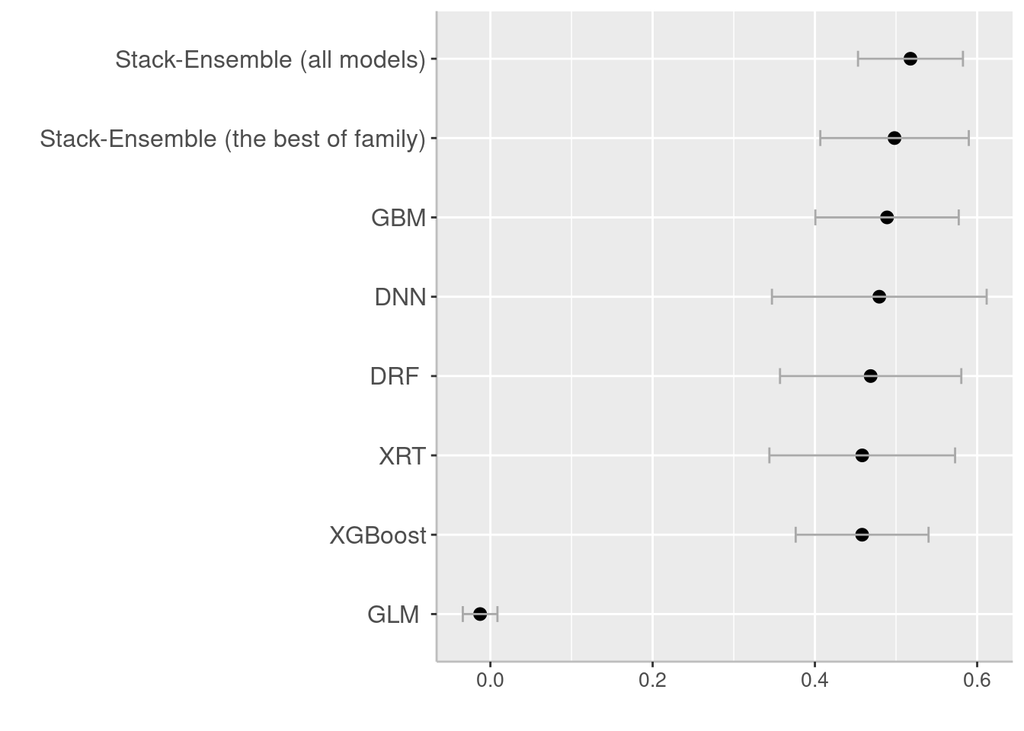

```r
print(cv.R2.p)
```

## Model Performance

### The best ML

```r
per.best.train<-h2o.performance(best_ML, h_train)
per.best.test<-h2o.performance(best_ML, h_test)
per.best.cv<-h2o.performance(best_stack, xval = TRUE)
#per.stack_best.train
per.best.test
```

```
## H2ORegressionMetrics: stackedensemble
##
## MSE:  668532.1
## RMSE:  817.6381
## MAE:  652.089
## RMSLE:  0.3148219
## Mean Residual Deviance :  668532.1
```

```r
#per.stack_best.cv
```

### The best Stack-Ensemble

```r
per.stack_best.train<-h2o.performance(best_stack, h_train)
per.stack_best.test<-h2o.performance(best_stack, h_test)
per.stack_best.cv<-h2o.performance(best_stack, xval = TRUE)
#per.stack_best.train
per.stack_best.test
```

```
## H2ORegressionMetrics: stackedensemble
##
## MSE:  668532.1
## RMSE:  817.6381
## MAE:  652.089
## RMSLE:  0.3148219
## Mean Residual Deviance :  668532.1
```

```r
#per.stack_best.cv
```

### The best GLM

```r
# ### Training
per.best_GLM.train<-h2o.performance(best_GLM, h_train)
per.best_GLM.test<-h2o.performance(best_GLM, h_test)
per.best_GLM.cv<-h2o.performance(best_GLM, xval = TRUE)
#per.best_GLM.train
per.best_GLM.test
```

```
## H2ORegressionMetrics: glm
##
## MSE:  1284905
## RMSE:  1133.537
## MAE:  941.4369
## RMSLE:  0.4388188
## Mean Residual Deviance :  1284905
## R^2 :  -0.009534228
## Null Deviance :187613729
## Null D.o.F. :145
## Residual Deviance :187596158
## Residual D.o.F. :69
## AIC :2623.995
```

```r
#per.best_GLM.cv
```

### The best DRF

```r
# ### Training
per.best_DRF.train<-h2o.performance(best_DRF, h_train)
per.best_DRF.test<-h2o.performance(best_DRF, h_test)
per.best_DRF.cv<-h2o.performance(best_DRF, xval = TRUE)
#per.best_DRF.train
per.best_DRF.test
```

```
## H2ORegressionMetrics: drf
##
## MSE:  688549.3
## RMSE:  829.7887
## MAE:  674.4042
## RMSLE:  0.3265623
## Mean Residual Deviance :  688549.3
```

```r
#per.best_DRF.cv
```

### The best XRT

```r
# ### Training
per.best_XRT.train<-h2o.performance(best_XRT, h_train)
per.best_XRT.test<-h2o.performance(best_XRT, h_test)
per.best_XRT.cv<-h2o.performance(best_XRT, xval = TRUE)
#per.best_XRT.train
per.best_XRT.test
```

```
## H2ORegressionMetrics: drf
##
## MSE:  673675.9
## RMSE:  820.7776
## MAE:  660.4489
## RMSLE:  0.3218251
## Mean Residual Deviance :  673675.9
```

```r
#per.best_XRT.cv
```

### The best GBM

```r
# ### Training
per.best_GBM.train<-h2o.performance(best_GBM, h_train)
per.best_GBM.test<-h2o.performance(best_GBM, h_test)
per.best_GBM.cv<-h2o.performance(best_GBM, xval = TRUE)
#per.best_GBM.train
per.best_GBM.test
```

```
## H2ORegressionMetrics: gbm
##
## MSE:  679859.8
## RMSE:  824.5361
## MAE:  650.9301
## RMSLE:  0.3168129
## Mean Residual Deviance :  679859.8
```

```r
#per.best_GBM.cv
```

### The best XGBoost

```r
# ### Training
per.best_XGBoost.train<-h2o.performance(best_XGBoost, h_train)
per.best_XGBoost.test<-h2o.performance(best_XGBoost, h_test)
per.best_XGBoost.cv<-h2o.performance(best_XGBoost, xval = TRUE)
#per.best_XGBoost.train
per.best_XGBoost.test
```

```
## H2ORegressionMetrics: xgboost
##
## MSE:  705947.9
## RMSE:  840.2071
## MAE:  684.6763
## RMSLE:  0.3210752
## Mean Residual Deviance :  705947.9
```

```r
#per.best_XGBoost.cv
```

### The best DNN

```r
# ### Training
per.best_DNN.train<-h2o.performance(best_DNN, h_train)
per.best_DNN.test<-h2o.performance(best_DNN, h_test)
per.best_DNN.cv<-h2o.performance(best_DNN, xval = TRUE)
#per.best_DNN.train
per.best_DNN.test
```

```
## H2ORegressionMetrics: deeplearning
##
## MSE:  924770.4
## RMSE:  961.6498
## MAE:  727.2163
## RMSLE:  0.356682
## Mean Residual Deviance :  924770.4
```

```r
#per.best_DNN.cv
```

## Model Comparison - Training/CV/Test

## RMSE

```r
d_rmse <- data.frame(Models = c("GLM ",
                                   "DRF ",
                                   "XRT",
                                   "GBM",
                                   "XGBoost",
                                   "DNN",
                                   "Stack-Ensemble",
                                   "Best-ML"
),
stringsAsFactors = FALSE)

d_rmse$Training <- NA
d_rmse$CV <- NA
d_rmse$Test <- NA

## Training
d_rmse[1, ]$Training<-h2o.rmse(h2o.performance(best_GLM, newdata = h_train))
d_rmse[2, ]$Training<-h2o.rmse(h2o.performance(best_DRF, newdata = h_train))
d_rmse[3, ]$Training<-h2o.rmse(h2o.performance(best_XRT, newdata = h_train))
d_rmse[4, ]$Training<-h2o.rmse(h2o.performance(best_GBM, newdata = h_train))
d_rmse[5, ]$Training<-h2o.rmse(h2o.performance(best_XGBoost, newdata = h_train))
d_rmse[6, ]$Training<-h2o.rmse(h2o.performance(best_DNN, newdata = h_train))
d_rmse[7, ]$Training<-h2o.rmse(h2o.performance(best_stack, newdata = h_train))
d_rmse[8, ]$Training<-h2o.rmse(h2o.performance(best_ML, newdata = h_train))

## Cross_Validation
d_rmse[1, ]$CV<-h2o.rmse(h2o.performance(best_GLM, xval = TRUE))
d_rmse[2, ]$CV<-h2o.rmse(h2o.performance(best_DRF, xval = TRUE))
d_rmse[3, ]$CV<-h2o.rmse(h2o.performance(best_XRT, xval = TRUE))
d_rmse[4, ]$CV<-h2o.rmse(h2o.performance(best_GBM, xval = TRUE))
d_rmse[5, ]$CV<-h2o.rmse(h2o.performance(best_XGBoost, xval = TRUE))
d_rmse[6, ]$CV<-h2o.rmse(h2o.performance(best_DNN, xval = TRUE))
d_rmse[7, ]$CV<-h2o.rmse(h2o.performance(best_stack, xval = TRUE))
d_rmse[8, ]$CV<-h2o.rmse(h2o.performance(best_ML, xval = TRUE))

##  Test data
d_rmse[1, ]$Test<-h2o.rmse(h2o.performance(best_GLM, newdata = h_test))
d_rmse[2, ]$Test<-h2o.rmse(h2o.performance(best_DRF, newdata = h_test))
d_rmse[3, ]$Test<-h2o.rmse(h2o.performance(best_XRT, newdata = h_test))
d_rmse[4, ]$Test<-h2o.rmse(h2o.performance(best_GBM, newdata = h_test))
d_rmse[5, ]$Test<-h2o.rmse(h2o.performance(best_XGBoost, newdata = h_test))
d_rmse[6, ]$Test<-h2o.rmse(h2o.performance(best_DNN, newdata = h_test))
d_rmse[7, ]$Test<-h2o.rmse(h2o.performance(best_stack, newdata = h_test))
d_rmse[8, ]$Test<-h2o.rmse(h2o.performance(best_ML, newdata = h_test))

write.csv(d_rmse, "rmse_all_models.csv", row.names = F)
# Show Comparison (rmse: Lower = Better)
datatable(d_rmse, rownames = FALSE, options = list(pageLength = 10, scrollX = TRUE, round)) %>%
  formatRound(columns = -1, digits = 3)
```

| Models | Training | CV | Test |
| --- | --- | --- | --- |
| GLM | 1210.38803992049 | 1211.72513897147 | 1133.53658657833 |
| DRF | 396.078743798883 | 870.240008832783 | 829.788735044148 |
| XRT | 424.711327286938 | 883.691960188016 | 820.777597732689 |
| GBM | 437.573818633636 | 857.291803396568 | 824.536117120052 |
| XGBoost | 397.584511113615 | 885.08429234975 | 840.207080450214 |
| DNN | 452.51061004475 | 859.30048489285 | 961.649814432163 |
| Stack-Ensemble | 404.772650159439 | 836.028103543683 | 817.638119462312 |
| Best-ML | 404.772650159439 | 836.028103543683 | 817.638119462312 |

## MAE

```r
d_mae <- data.frame(Models = c("GLM ",
                                   "DRF ",
                                   "XRT",
                                   "GBM",
                                   "XGBoost",
                                   "DNN",
                                   "Stack-Ensemble",
                                   "Best-ML"
),
stringsAsFactors = FALSE)

d_mae$Training <- NA
d_mae$CV <- NA
d_mae$Test <- NA

## Training
d_mae[1, ]$Training<-h2o.mae(h2o.performance(best_GLM, newdata = h_train))
d_mae[2, ]$Training<-h2o.mae(h2o.performance(best_DRF, newdata = h_train))
d_mae[3, ]$Training<-h2o.mae(h2o.performance(best_XRT, newdata = h_train))
d_mae[4, ]$Training<-h2o.mae(h2o.performance(best_GBM, newdata = h_train))
d_mae[5, ]$Training<-h2o.mae(h2o.performance(best_XGBoost, newdata = h_train))
d_mae[6, ]$Training<-h2o.mae(h2o.performance(best_DNN, newdata = h_train))
d_mae[7, ]$Training<-h2o.mae(h2o.performance(best_stack, newdata = h_train))
d_mae[8, ]$Training<-h2o.mae(h2o.performance(best_ML, newdata = h_train))

## Cross_Validation
d_mae[1, ]$CV<-h2o.mae(h2o.performance(best_GLM, xval = TRUE))
d_mae[2, ]$CV<-h2o.mae(h2o.performance(best_DRF, xval = TRUE))
d_mae[3, ]$CV<-h2o.mae(h2o.performance(best_XRT, xval = TRUE))
d_mae[4, ]$CV<-h2o.mae(h2o.performance(best_GBM, xval = TRUE))
d_mae[5, ]$CV<-h2o.mae(h2o.performance(best_XGBoost, xval = TRUE))
d_mae[6, ]$CV<-h2o.mae(h2o.performance(best_DNN, xval = TRUE))
d_mae[7, ]$CV<-h2o.mae(h2o.performance(best_stack, xval = TRUE))
d_mae[8, ]$CV<-h2o.mae(h2o.performance(best_ML, xval = TRUE))

##  Test data
d_mae[1, ]$Test<-h2o.mae(h2o.performance(best_GLM, newdata = h_test))
d_mae[2, ]$Test<-h2o.mae(h2o.performance(best_DRF, newdata = h_test))
d_mae[3, ]$Test<-h2o.mae(h2o.performance(best_XRT, newdata = h_test))
d_mae[4, ]$Test<-h2o.mae(h2o.performance(best_GBM, newdata = h_test))
d_mae[5, ]$Test<-h2o.mae(h2o.performance(best_XGBoost, newdata = h_test))
d_mae[6, ]$Test<-h2o.mae(h2o.performance(best_DNN, newdata = h_test))
d_mae[7, ]$Test<-h2o.mae(h2o.performance(best_stack, newdata = h_test))
d_mae[8, ]$Test<-h2o.mae(h2o.performance(best_ML, newdata = h_test))

write.csv(d_mae, "mae_all_models.csv", row.names = F)
# Show Comparison (mae: Lower = Better)
datatable(d_mae, rownames = FALSE, options = list(pageLength = 10, scrollX = TRUE, round)) %>%
  formatRound(columns = -1, digits = 3)
```

| Models | Training | CV | Test |
| --- | --- | --- | --- |
| GLM | 1011.79357099052 | 1012.98891610585 | 941.436884682341 |
| DRF | 294.32593445838 | 635.981215313602 | 674.404156124497 |
| XRT | 315.38328718565 | 645.613309202842 | 660.44888117542 |
| GBM | 317.840883076548 | 644.111070893112 | 650.930108287166 |
| XGBoost | 274.353213408147 | 657.019780496227 | 684.676282908819 |
| DNN | 317.566815021524 | 635.105839931944 | 727.216296496355 |
| Stack-Ensemble | 309.896060708218 | 637.330506542512 | 652.08895060084 |
| Best-ML | 309.896060708218 | 637.330506542512 | 652.08895060084 |

## R2

```r
d_r2 <- data.frame(Models = c("GLM ",
                                   "DRF ",
                                   "XRT",
                                   "GBM",
                                   "XGBoost",
                                   "DNN",
                                   "Stack-Ensemble",
                                   "Best-ML"
),
stringsAsFactors = FALSE)

d_r2$Training <- NA
d_r2$CV <- NA
d_r2$Test <- NA

## Training

d_r2[1, ]$Training<-h2o.r2(h2o.performance(best_GLM, newdata = h_train))
d_r2[2, ]$Training<-h2o.r2(h2o.performance(best_DRF, newdata = h_train))
d_r2[3, ]$Training<-h2o.r2(h2o.performance(best_XRT, newdata = h_train))
d_r2[4, ]$Training<-h2o.r2(h2o.performance(best_GBM, newdata = h_train))
d_r2[5, ]$Training<-h2o.r2(h2o.performance(best_XGBoost, newdata = h_train))
d_r2[6, ]$Training<-h2o.r2(h2o.performance(best_DNN, newdata = h_train))
d_r2[7, ]$Training<-h2o.r2(h2o.performance(best_stack, newdata = h_train))
d_r2[8, ]$Training<-h2o.r2(h2o.performance(best_ML, newdata = h_train))

## Cross_Validation

d_r2[1, ]$CV<-h2o.r2(h2o.performance(best_GLM, xval = TRUE))
d_r2[2, ]$CV<-h2o.r2(h2o.performance(best_DRF, xval = TRUE))
d_r2[3, ]$CV<-h2o.r2(h2o.performance(best_XRT, xval = TRUE))
d_r2[4, ]$CV<-h2o.r2(h2o.performance(best_GBM, xval = TRUE))
d_r2[5, ]$CV<-h2o.r2(h2o.performance(best_XGBoost, xval = TRUE))
d_r2[6, ]$CV<-h2o.r2(h2o.performance(best_DNN, xval = TRUE))
d_r2[7, ]$CV<-h2o.r2(h2o.performance(best_stack, xval = TRUE))
d_r2[8, ]$CV<-h2o.r2(h2o.performance(best_ML, xval = TRUE))

##  Test data

d_r2[1, ]$Test<-h2o.r2(h2o.performance(best_GLM, newdata = h_test))
d_r2[2, ]$Test<-h2o.r2(h2o.performance(best_DRF, newdata = h_test))
d_r2[3, ]$Test<-h2o.r2(h2o.performance(best_XRT, newdata = h_test))
d_r2[4, ]$Test<-h2o.r2(h2o.performance(best_GBM, newdata = h_test))
d_r2[5, ]$Test<-h2o.r2(h2o.performance(best_XGBoost, newdata = h_test))
d_r2[6, ]$Test<-h2o.r2(h2o.performance(best_DNN, newdata = h_test))
d_r2[7, ]$Test<-h2o.r2(h2o.performance(best_stack, newdata = h_test))
d_r2[8, ]$Test<-h2o.r2(h2o.performance(best_ML, newdata = h_test))

write.csv(d_r2, "r2_all_models.csv", row.names = F)
# Show Comparison (r2: Lower = Better)
datatable(d_r2, rownames = FALSE, options = list(pageLength = 10, scrollX = TRUE, round)) %>%
  formatRound(columns = -1, digits = 3)
```

| Models | Training | CV | Test |
| --- | --- | --- | --- |
| GLM | 0.000100023967527174 | -0.00211034779510944 | -0.00953422753575994 |
| DRF | 0.892929363990299 | 0.483125148226434 | 0.459015237345414 |
| XRT | 0.87688952736065 | 0.467022201994171 | 0.470701147783097 |
| GBM | 0.869319746433239 | 0.498391769974776 | 0.465842499336978 |
| XGBoost | 0.892113718479632 | 0.465341374805509 | 0.445345376352285 |
| DNN | 0.860245807957681 | 0.496038425260255 | 0.273419282849589 |
| Stack-Ensemble | 0.888177388361193 | 0.522966296439309 | 0.474742545116189 |
| Best-ML | 0.888177388361193 | 0.522966296439309 | 0.474742545116189 |

## Create a data-frame Model Perforamnce for the test data

```r
test.matrix <- data.frame(Models = c("GLM ",
                                        "DRF ",
                                        "XRT",
                                        "GBM",
                                        "XGBoost",
                                        "DNN",
                                        "Stack-Ensemble",
                                        "Best-ML"
                                        ),
                                        stringsAsFactors = FALSE)

test.matrix$MAE<-round((d_mae$Test),3)
test.matrix$RMSE<-round((d_rmse$Test),3)
test.matrix$R2<-round((d_r2$Test),3)

write.csv(test.matrix, "test_matrix_all_models.csv", row.names = F)
# Show Comparison (F1: high = Better)
datatable(test.matrix, rownames = FALSE, options = list(pageLength = 10, scrollX = TRUE, round)) %>%
  formatRound(columns = -1, digits = 3)
```

| Models | MAE | RMSE | R2 |
| --- | --- | --- | --- |
| GLM | 941.437 | 1133.537 | -0.01 |
| DRF | 674.404 | 829.789 | 0.459 |
| XRT | 660.449 | 820.778 | 0.471 |
| GBM | 650.93 | 824.536 | 0.466 |
| XGBoost | 684.676 | 840.207 | 0.445 |
| DNN | 727.216 | 961.65 | 0.273 |
| Stack-Ensemble | 652.089 | 817.638 | 0.475 |
| Best-ML | 652.089 | 817.638 | 0.475 |

```r
#best_ML<- h2o.loadModel("StackedEnsemble_AllModels_3_AutoML_1_20211102_184016")
```

### 1: 1 Plot Ovserved vs Predicted Yields

```r
bestML.test<-as.data.frame(h2o.predict(object = best_ML, newdata = h_test))
test.xy<-test.mf[,c(1:5,17)]
test.xy$Predicted<-bestML.test$predict
write.csv(test.xy, "test_pred.csv", row.names = F)
```

```r
tiff( file="FIGURE_Obs_Pred_aman_Yield.tif",
width=5.5, height=5, units="in", res=600)

pred.yield.test<-ggplot(data=test.xy, aes(x=YIELD, y=Predicted))+
  geom_point(size = 1.0,colour = "grey")+
  geom_smooth(method = "lm", se = FALSE, colour="black",size=0.5)+
  scale_x_continuous(limits=c(0,10000), breaks=seq(0, 10000, 2000))+
  scale_y_continuous(limits=c(0,10000), breaks=seq(0, 10000, 2000)) +
  theme_light() +
  theme(
    panel.background = element_rect(fill = "white",colour = "gray75",size = 0.5, linetype = "solid"),
    axis.line = element_line(colour = "grey"),
    panel.grid.major = element_blank(),
    axis.title.x=element_blank(),
    axis.title.y=element_blank(),
    axis.text.x=element_text(size=14, colour="black"),
    axis.text.y=element_text(size=14,angle = 90,vjust = 0.5, hjust=0.5, colour='black'))+
  geom_abline(slope=1, intercept=0,linetype="dashed",size=0.5)
print(pred.yield.test)
dev.off()
```

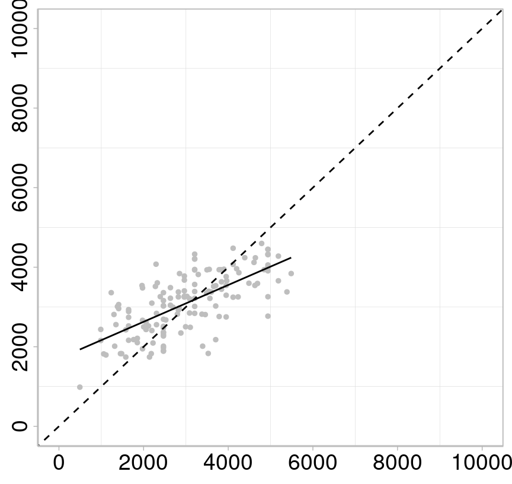

```r
print(pred.yield.test)
```

# Interpretable Machine Learning

The following code extracts these items for the h2o example:

## Create Model Explainer for Best_ML

```r
pred_fun_best_ML <- function(object, newdata)  {
  results <- as.vector(h2o.predict(object, as.h2o(newdata)))
  return(results)
}
```

### Explainer For Training Data

```r
explainer_train <- DALEX::explain(
  model = best_ML,
  type="regression",
  data = x_train,
  y = y_train,
  predict_function = pred_fun_best_ML,
  label = "The Best ML- Training"
)
```

## Permutation-based feature importance

```r
vip_train <- variable_importance(explainer_train, type="difference")
datatable(as.data.frame(vip_train),
          rownames = FALSE, options = list(pageLength = 10, scrollX = TRUE, round)) %>%
  formatRound(columns = -1, digits = 4)
```

```r
tiff( file="FIGURE_VIP.tif",
      width=6, height=18, units="in", res=600)
p.vip_train<-plot(vip_train)
print(p.vip_train)
dev.off()
```

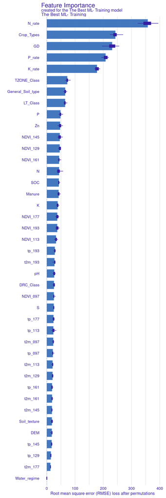

```r
print(p.vip_train)
```

### Create VIP table

```r
vip_train_stat<-vip_train %>%
  group_by(variable) %>%
  summarise(mean.loss = mean(dropout_loss, na.rm = TRUE),
            sd.loss = sd(dropout_loss, na.rm = TRUE),
            n.loss = n()) %>%
  mutate(se.loss = sd.loss / sqrt(n.loss),
         lower.ci.loss = mean.loss - qt(1 - (0.05 / 2), n.loss - 1) * se.loss,
         upper.ci.loss = mean.loss + qt(1 - (0.05 / 2), n.loss - 1) * se.loss)

vip_train_stat<-filter(vip_train_stat,  variable != "_baseline_")
vip_train_stat<-filter(vip_train_stat,  variable != "_full_model_")

vip_train_stat$Scale_VIP<-(vip_train_stat$mean.loss - min(vip_train_stat$mean.loss))/
                         (max(vip_train_stat$mean.loss)-min(vip_train_stat$mean.loss))

datatable(as.data.frame(vip_train_stat),
          rownames = FALSE, options = list(pageLength = 10, scrollX = TRUE, round)) %>%
  formatRound(columns = -1, digits = 4)
write.csv(vip_train_stat, "vip_stat_train.csv", row.names = F)
```

# Partial-dependence Profiles

```r
vip_stat_df<-vip_train_stat %>%
   arrange(desc(mean.loss))

var.names.stack=vip_stat_df[1]
var_1st=var.names.stack[1,]$variable
var_1st
```

```
## [1] "N_rate"
```

```r
var_2nd=var.names.stack[2,]$variable
var_2nd
```

```
## [1] "Crop_Types"
```

```r
var_3rd=var.names.stack[3,]$variable
var_3rd
```

```
## [1] "GD"
```

```r
var_4th=var.names.stack[4,]$variable
var_4th
```

```
## [1] "P_rate"
```

```r
var_5th=var.names.stack[5,]$variable
var_5th
```

```
## [1] "K_rate"
```

### PDP Plot of of 1st Important variable

```r
pdp_1st <- variable_effect(explainer_train,
                                      variable =  var_1st,
                                      type = "partial_dependency")
write.csv(pdp_1st , "PDP_1st.csv", row.names = F)
```

```r
tiff( file="FIGURE_PDP_1st.tif",
width=5, height=5, units="in", res=600)
pdp_1st.p<-plot(pdp_1st)
print(pdp_1st.p)
dev.off()
```

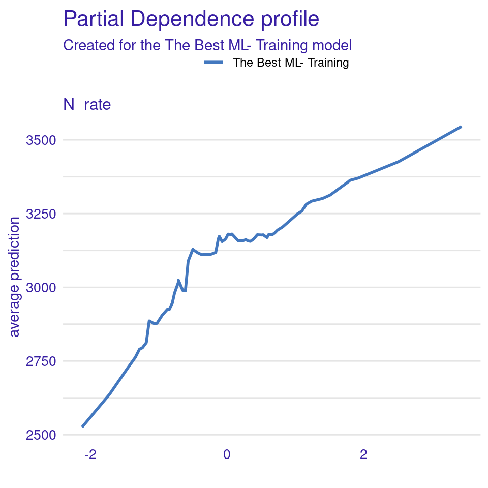

```r
print(pdp_1st.p)
```

### PDP Plot of of 2nd Important variable

```r
pdp_2nd <- variable_effect(explainer_train,
                                      variable =  var_2nd,
                                      type = "partial_dependency")
write.csv(pdp_2nd , "PDP_2nd.csv", row.names = F)
```

```r
tiff( file="FIGURE_PDP_2nd.tif",
width=5, height=5, units="in", res=600)
pdp_2nd.p<-plot(pdp_2nd)
print(pdp_2nd.p)
dev.off()
```

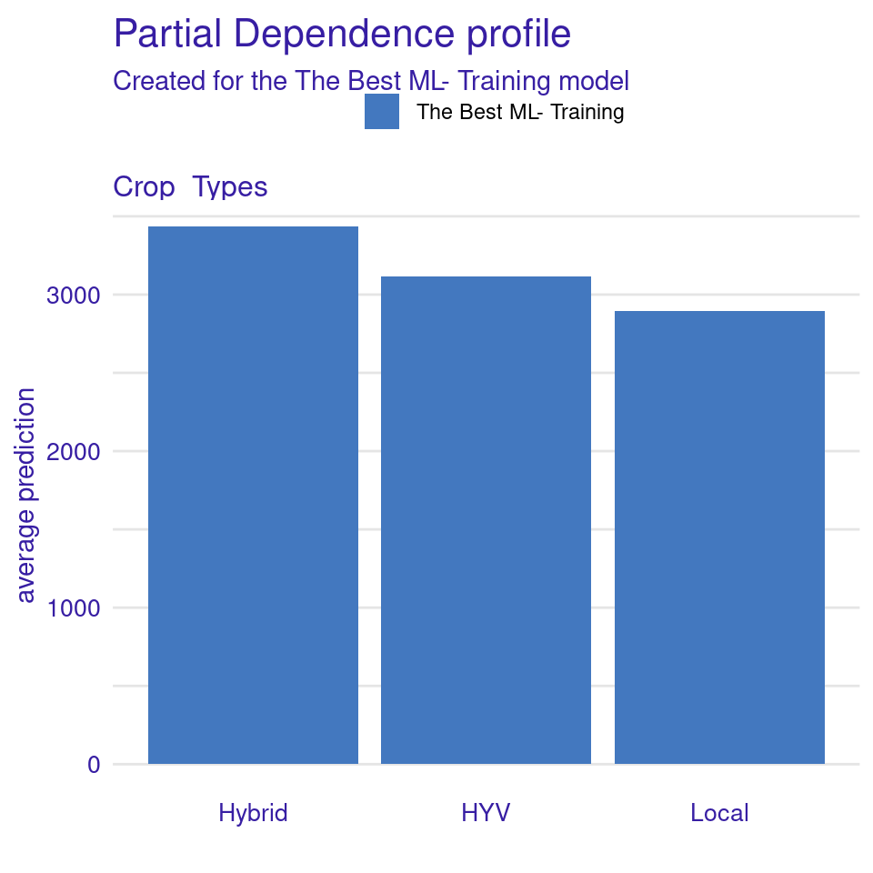

```r
print(pdp_2nd.p)
```

### PDP Plot of of 3rd Important variable

```r
pdp_3rd <- variable_effect(explainer_train,
                                      variable =  var_3rd,
                                      type = "partial_dependency")
write.csv(pdp_3rd , "PDP_3rd.csv", row.names = F)
```

```r
tiff( file="FIGURE_PDP_3rd_Aman.tif",
width=5, height=5, units="in", res=600)
pdp_3rd.p<-plot(pdp_3rd)
print(pdp_3rd.p)
dev.off()
```

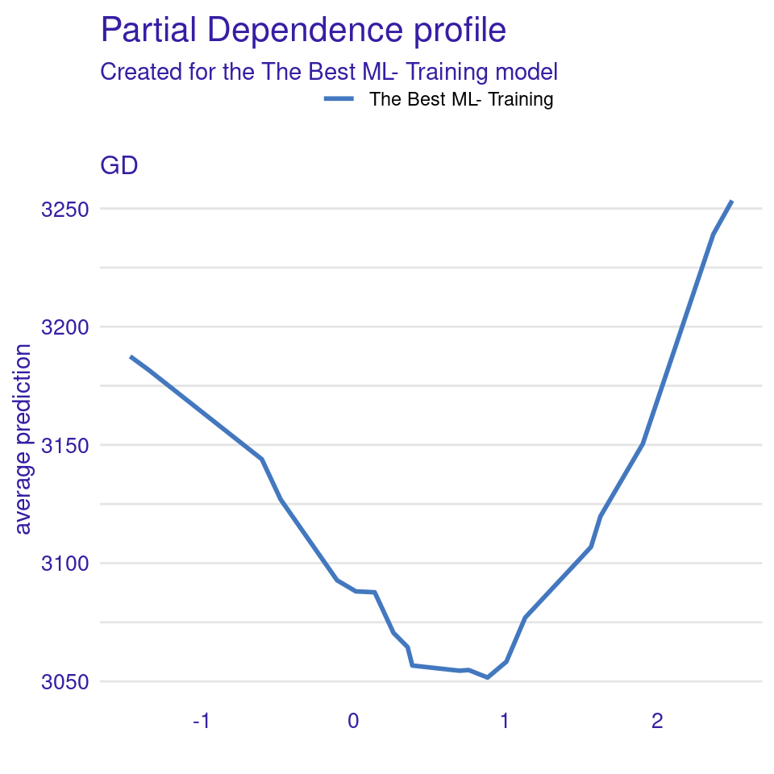

```r
print(pdp_3rd.p)
```

### PDP Plot of of 4th Important variable

```r
pdp_4th <- variable_effect(explainer_train,
                                      variable =  var_4th,
                                      type = "partial_dependency")
write.csv(pdp_4th , "PDP_4th.csv", row.names = F)
```

```r
tiff( file="FIGURE_PDP_4th.tif",
width=5, height=5, units="in", res=600)
pdp_4th.p<-plot(pdp_4th)
print(pdp_4th.p)
dev.off()
```

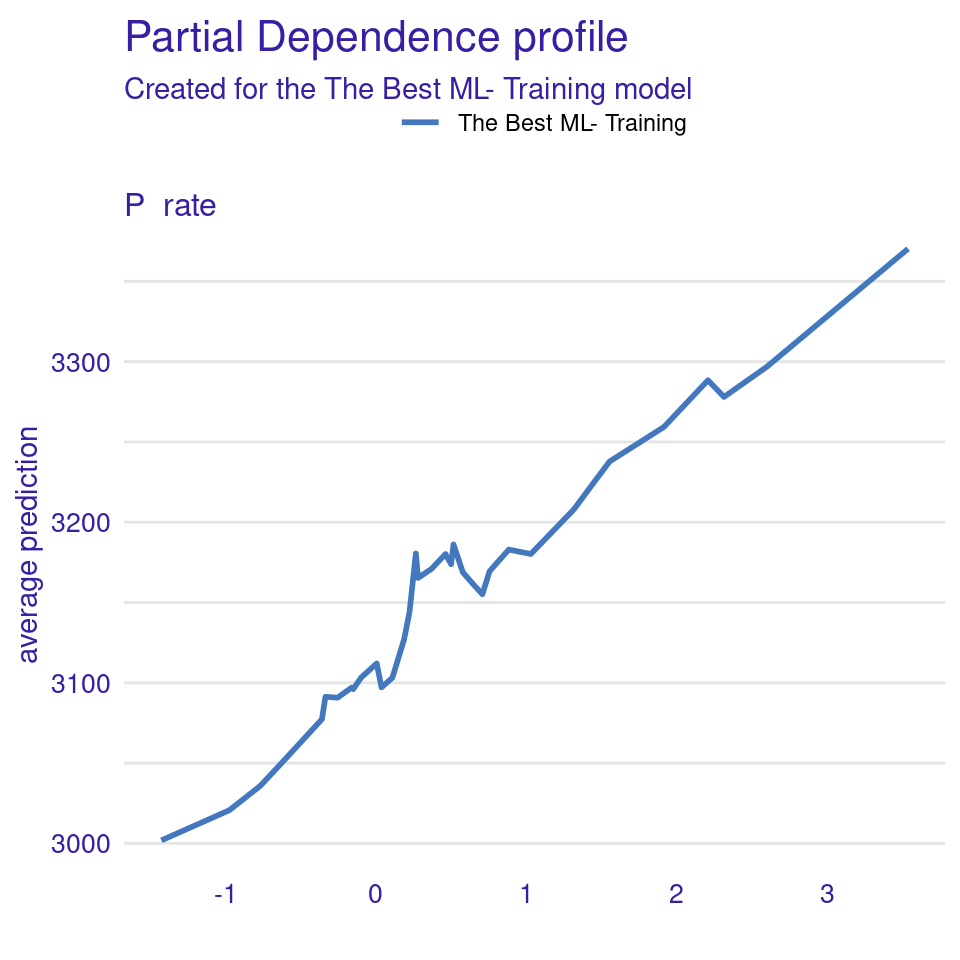

```r
print(pdp_4th.p)
```

### PDP Plot of of 5th Important variable

```r
pdp_5th <- variable_effect(explainer_train,
                                      variable =  var_5th,
                                      type = "partial_dependency")
write.csv(pdp_5th , "PDP_5th.csv", row.names = F)
```

```r
tiff( file="FIGURE_PDP_5th.tif",
width=5, height=5, units="in", res=600)
pdp_5th.p<-plot(pdp_5th)
print(pdp_5th.p)
dev.off()
```

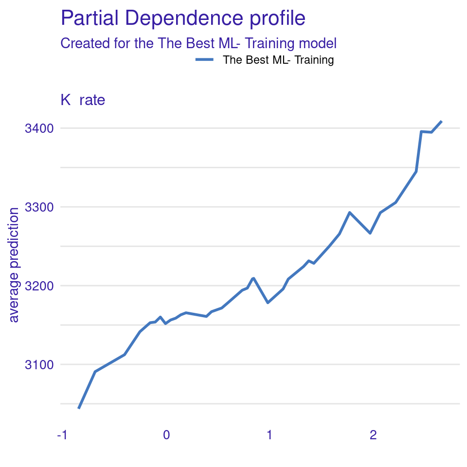

```r
print(pdp_5th.p)
```

## Partial, Accumulated and Local-dependence profils

```r
## !st important
pd_stack_1st <- model_profile(explainer = explainer_train, type = "partial", variables = var_1st)
ld_stack_1st <- model_profile(explainer = explainer_train, type = "conditional", variables = var_1st)
al_stack_1st <- model_profile(explainer = explainer_train, type = "accumulated", variables = var_1st)

write.csv(pd_stack_1st$agr_profiles, "partial_dependence_1st.csv")
write.csv(ld_stack_1st$agr_profiles, "local_dependence_1st.csv")
write.csv(al_stack_1st$agr_profiles, "accumulate_local_1st.csv")

# 2nd Important
pd_stack_2nd <- model_profile(explainer = explainer_train, type = "partial", variables = var_2nd)
ld_stack_2nd <- model_profile(explainer = explainer_train, type = "conditional", variables = var_2nd)
al_stack_2nd <- model_profile(explainer = explainer_train, type = "accumulated", variables = var_2nd)

write.csv(pd_stack_2nd$agr_profiles, "partial_dependence_2nd.csv")
write.csv(ld_stack_2nd$agr_profiles, "local_dependence_2nd.csv")
write.csv(al_stack_2nd$agr_profiles, "accumulated_local_2nd.csv")

# 3rd Important
pd_stack_3rd <- model_profile(explainer = explainer_train, type = "partial", variables = var_3rd)
ld_stack_3rd <- model_profile(explainer = explainer_train, type = "conditional", variables = var_3rd)
al_stack_3rd <- model_profile(explainer = explainer_train, type = "accumulated", variables = var_3rd)

write.csv(pd_stack_3rd$agr_profiles, "partial_dependence_3rd.csv")
write.csv(ld_stack_3rd$agr_profiles, "local_dependence_3rd.csv")
write.csv(al_stack_3rd$agr_profiles, "accumulated_local_3rd.csv")

# 4th Important
pd_stack_4th <- model_profile(explainer = explainer_train, type = "partial", variables = var_4th)
ld_stack_4th <- model_profile(explainer = explainer_train, type = "conditional", variables = var_4th)
al_stack_4th <- model_profile(explainer = explainer_train, type = "accumulated", variables = var_4th)

write.csv(pd_stack_4th$agr_profiles, "partial_dependence_4th.csv")
write.csv(ld_stack_4th$agr_profiles, "local_dependence_4th.csv")
write.csv(al_stack_4th$agr_profiles, "accumulated_local_4th.csv")

# 5th Important
pd_stack_5th <- model_profile(explainer = explainer_train, type = "partial", variables = var_5th)
ld_stack_5th <- model_profile(explainer = explainer_train, type = "conditional", variables = var_5th)
al_stack_5th <- model_profile(explainer = explainer_train, type = "accumulated", variables = var_5th)

write.csv(pd_stack_5th$agr_profiles, "partial_dependence_5th.csv")
write.csv(ld_stack_5th$agr_profiles, "local_dependence_5th.csv")
write.csv(al_stack_5th$agr_profiles, "accumulated_local_5th.csv")
```

## Feature interactions

```r
# create predictor object to pass to explainer functions
mod <- Predictor$new(best_ML, data =x_train)
inter<-Interaction$new(mod)
```

[output not shown]

[output not shown]

[output not shown]

[output not shown]

[output not shown]

[output not shown]

[output not shown]

[output not shown]

[output not shown]

[output not shown]

[output not shown]

[output not shown]

[output not shown]

[output not shown]

[output not shown]

[output not shown]

[output not shown]

```r
tiff( file="FIGURE_Interaction.tif",
width=6, height=18, units="in", res=600)
p.inter<-plot(inter)
print(p.inter)
dev.off()
```

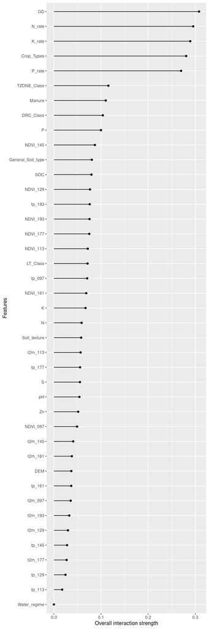

```r
print(p.inter)
```

```r
dat<-inter$results
write.csv(dat, "Feature_Interaction.csv", row.names=F)
```